# Expected Value in 2019 Given Age, Savings, Shocks, Kids, Educaiton and Marriage

[Fan Wang](https://fanwangecon.github.io/)

2020-08-07

# 1 2019 Full States EV and EC of One Check

This is the example vignette for function: [**snw_evuvw19_jaeemk**](https://github.com/FanWangEcon/PrjOptiSNW/blob/master/PrjOptiSNW/splanneralt/snw_evuvw19_jaeemk.m) from the [**PrjOptiSNW Package**](https://fanwangecon.github.io/PrjOptiSNW/)**.** 2019 integrated over VU and VW, given optimal savings choices, unemployment shocks and various expectations.

## 1.1 Test SNW_EVUVW19_JAEEMK Defaults

Call the function with defaults.

```
clear all;
st_solu_type = 'bisec_vec';

% Solve the VFI Problem and get Value Function
mp_params = snw_mp_param('default_docdense');
mp_params('beta') = 0.95;
% mp_params = snw_mp_param('default_dense');
mp_controls = snw_mp_control('default_test');

% set Unemployment Related Variables
mp_params('a2_covidyr') = mp_params('a2_covidyr_manna_heaven');
% mp_params('a2_covidyr') = mp_params('a2_covidyr_tax_fully_pay');

% Solve for Unemployment Values
mp_controls('bl_print_vfi') = false;
mp_controls('bl_print_vfi_verbose') = true;
mp_controls('bl_print_ds') = false;
mp_controls('bl_print_ds_verbose') = false;
mp_controls('bl_print_precompute') = false;
mp_controls('bl_print_precompute_verbose') = false;
mp_controls('bl_print_a4chk') = false;
mp_controls('bl_print_a4chk_verbose') = false;
mp_controls('bl_print_evuvw20_jaeemk') = false;
mp_controls('bl_print_evuvw20_jaeemk_verbose') = false;

% Solve the Model to get V working and unemployed
[V_ss,ap_ss,cons_ss,mp_valpol_more_ss] = snw_vfi_main_bisec_vec(mp_params, mp_controls);

Completed SNW_VFI_MAIN_BISEC_VEC;SNW_MP_PARAM=default_docdense;SNW_MP_CONTROL=default_test;time=488.7831
----------------------------------------
xxxxxxxxxxxxxxxxxxxxxxxxxxxxxxxxxxxxxxxx
CONTAINER NAME: mp_outcomes ND Array (Matrix etc)
xxxxxxxxxxxxxxxxxxxxxxxxxxxxxxxxxxxxxxxx
                i    idx    ndim     numel      rowN      colN           sum         mean       std      coefvari      min        max
                _    ___    ____    ________    ____    _________    ___________    _______    ______    ________    ________    ______

    V_VFI       1     1      6      4.37e+07     83     5.265e+05    -1.2728e+08    -2.9126    20.655    -7.0915      -485.24    16.447
    ap_VFI      2     2      6      4.37e+07     83     5.265e+05     1.3962e+09      31.95    36.423       1.14            0    160.21
    cons_VFI    3     3      6      4.37e+07     83     5.265e+05     2.3374e+08     5.3487    8.4439     1.5787     0.036717    141.66

```

[output cut: 170 more lines]

```
    r83      0.2179     0.21844     0.22216     0.23228     0.25197    116.37     122.19     128.21     134.43     140.84

[Phi_true] = snw_ds_main(mp_params, mp_controls, ap_ss, cons_emp_2020, mp_valpol_more_ss);

Completed SNW_DS_MAIN;SNW_MP_PARAM=default_docdense;SNW_MP_CONTROL=default_test;time=1911.1684

% Get Matrixes
cl_st_precompute_list = {'a', ...
    'inc', 'inc_unemp', 'spouse_inc', 'spouse_inc_unemp', 'ref_earn_wageind_grid',...
    'ap_idx_lower_ss', 'ap_idx_higher_ss', 'ap_idx_lower_weight_ss'};
mp_controls('bl_print_precompute_verbose') = false;
[mp_precompute_res] = snw_hh_precompute(mp_params, mp_controls, cl_st_precompute_list, ap_ss, Phi_true);

Wage quintile cutoffs=0.4645     0.71528      1.0335      1.5632
Completed SNW_HH_PRECOMPUTE;SNW_MP_PARAM=default_docdense;SNW_MP_CONTROL=default_test;time cost=358.215
```

## 1.2 Solve for 2019 Evuvw With 0 and 2 Checks

```
% Call Function
welf_checks = 0;
[ev19_jaeemk_check0, ec19_jaeemk_check0, ev20_jaeemk_check0, ec20_jaeemk_check0] = snw_evuvw19_jaeemk(...
    welf_checks, st_solu_type, mp_params, mp_controls, ...
    V_emp_2020, cons_emp_2020, V_unemp_2020, cons_unemp_2020, mp_precompute_res);

Completed SNW_A4CHK_WRK_BISEC_VEC;welf_checks=0;TR=0.0017225;SNW_MP_PARAM=default_docdense;SNW_MP_CONTROL=default_test;time cost=68.836
Completed SNW_A4CHK_UNEMP_BISEC_VEC;welf_checks=0;TR=0.0017225;xi=0.5;b=0.5;SNW_MP_PARAM=default_docdense;SNW_MP_CONTROL=default_test;time cost=69.8961
Completed SNW_EVUVW20_JAEEMK;SNW_MP_PARAM=default_docdense;SNW_MP_CONTROL=default_test;timeEUEC=8.2469
Completed SNW_EVUVW19_JAEEMK;SNW_MP_PARAM=default_docdense;SNW_MP_CONTROL=default_test;time=5058.1482
----------------------------------------
xxxxxxxxxxxxxxxxxxxxxxxxxxxxxxxxxxxxxxxx
CONTAINER NAME: mp_outcomes ND Array (Matrix etc)
xxxxxxxxxxxxxxxxxxxxxxxxxxxxxxxxxxxxxxxx
                   i    idx    ndim      numel       rowN      colN           sum         mean       std      coefvari      min        max
                   _    ___    ____    __________    ____    _________    ___________    _______    ______    ________    ________    ______

    ec19_jaeemk    1     1      6      4.3173e+07     82     5.265e+05     1.9762e+08     4.5774    5.3272     1.1638     0.036494    64.569
    ec20_jaeemk    2     2      6        4.37e+07     83     5.265e+05     2.3357e+08     5.3448    8.4447       1.58     0.033462    141.66
    ev19_jaeemk    3     3      6      4.3173e+07     82     5.265e+05    -1.2119e+08    -2.8072    20.003    -7.1255      -454.58    16.358
    ev20_jaeemk    4     4      6        4.37e+07     83     5.265e+05    -1.2937e+08    -2.9604    20.785     -7.021      -492.39    16.445

xxx TABLE:ec19_jaeemk xxxxxxxxxxxxxxxxxx
              c1          c2          c3          c4          c5       c526496    c526497    c526498    c526499    c526500
           ________    ________    ________    ________    ________    _______    _______    _______    _______    _______

    r1     0.036494    0.036494    0.037029    0.041925    0.048857    12.024     12.296     12.576     12.864     13.138
    r2     0.036494    0.036494    0.037029    0.041745    0.049665    12.268     12.541     12.822     13.111     13.382
    r3     0.037912    0.037912    0.038127    0.041994    0.050655    12.503     12.777      13.06     13.349     13.618
    r4     0.039293    0.039293    0.039401    0.043382    0.052052    12.761     13.036     13.319     13.607     13.842
    r5     0.040635    0.040635     0.04064    0.044725    0.053494     13.01     13.286     13.569     13.855     14.055
    r78      0.2179      0.2179      0.2179      0.2179      0.2179    27.797     28.793     29.808     30.995     32.447
    r79      0.2179      0.2179      0.2179      0.2179      0.2179    30.454     31.684     32.756     33.984     35.551
    r80      0.2179      0.2179      0.2179      0.2179      0.2179    33.715     35.537     37.399      38.98     40.213
    r81      0.2179      0.2179      0.2179      0.2179      0.2179     40.14     41.425     43.212     45.644     48.477
    r82      0.2179      0.2179      0.2179      0.2179      0.2179    52.118     55.559     58.496     60.127     62.893

xxx TABLE:ec20_jaeemk xxxxxxxxxxxxxxxxxx
              c1          c2          c3          c4          c5       c526496    c526497    c526498    c526499    c526500
           ________    ________    ________    ________    ________    _______    _______    _______    _______    _______
```

[output cut: 108 more lines]

```

xxx TABLE:ev20_jaeemk xxxxxxxxxxxxxxxxxx
             c1         c2         c3         c4         c5       c526496    c526497    c526498    c526499    c526500
           _______    _______    _______    _______    _______    _______    _______    _______    _______    _______

    r1     -275.12    -274.68    -272.28    -266.43    -257.32     14.436      14.53     14.623     14.715     14.806
    r2      -265.6    -265.16    -262.78    -257.01    -248.18     14.491     14.582     14.671      14.76     14.847
    r3     -256.09    -255.66    -253.32    -247.71    -239.31     14.546     14.633      14.72     14.805     14.889
    r4     -246.56    -246.15    -243.96    -238.69    -230.79     14.603     14.686     14.769      14.85     14.932
    r5     -237.94    -237.56     -235.5    -230.54    -223.08      14.65      14.73      14.81     14.888     14.967
    r79     -9.595     -9.584    -9.5115    -9.3234    -8.9958     2.4698     2.4801     2.4898     2.4989     2.5075
    r80    -8.6319    -8.6209    -8.5484    -8.3603    -8.0332      2.253      2.261     2.2685     2.2756     2.2822
    r81    -7.4426    -7.4316    -7.3591     -7.171    -6.8443     1.9749     1.9803     1.9855     1.9904      1.995
    r82    -5.8443    -5.8333    -5.7608    -5.5727    -5.2463      1.582     1.5851      1.588     1.5907     1.5933
    r83     -3.518     -3.507    -3.4345    -3.2464    -2.9207    0.97904    0.98004    0.98097    0.98185    0.98267
```

Differences between Checks in Expected Value and Expected Consumption

```
mn_V_U_gain_check = ev19_jaeemk_check2 - ev19_jaeemk_check0;
mn_MPC_U_gain_share_check = (ec19_jaeemk_check2 - ec19_jaeemk_check0)./(welf_checks*mp_params('TR'));
```

## 1.3 Param Results Define Frames

Define the matrix dimensions names and dimension vector values. Policy and Value Functions share the same ND dimensional structure.

```
% Grids:
age_grid = 18:99;
agrid = mp_params('agrid')';
eta_H_grid = mp_params('eta_H_grid')';
eta_S_grid = mp_params('eta_S_grid')';
ar_st_eta_HS_grid = string(cellstr([num2str(eta_H_grid', 'hz=%3.2f;'), num2str(eta_S_grid', 'wz=%3.2f')]));
edu_grid = [0,1];
marry_grid = [0,1];
kids_grid = (1:1:mp_params('n_kidsgrid'))';
% NaN(n_jgrid,n_agrid,n_etagrid,n_educgrid,n_marriedgrid,n_kidsgrid);
cl_mp_datasetdesc = {};
cl_mp_datasetdesc{1} = containers.Map({'name', 'labval'}, {'age', age_grid});
cl_mp_datasetdesc{2} = containers.Map({'name', 'labval'}, {'savings', agrid});
cl_mp_datasetdesc{3} = containers.Map({'name', 'labval'}, {'eta', 1:length(eta_H_grid)});
cl_mp_datasetdesc{4} = containers.Map({'name', 'labval'}, {'edu', edu_grid});
cl_mp_datasetdesc{5} = containers.Map({'name', 'labval'}, {'marry', marry_grid});
cl_mp_datasetdesc{6} = containers.Map({'name', 'labval'}, {'kids', kids_grid});
```

## 1.4 Analyze Difference in V and C with Check

The difference between V and V with Check, marginal utility gain given the check.

```
% Generate some Data
mp_support_graph = containers.Map('KeyType', 'char', 'ValueType', 'any');
mp_support_graph('cl_st_xtitle') = {'Savings States, a'};
mp_support_graph('st_legend_loc') = 'eastoutside';
mp_support_graph('bl_graph_logy') = true; % do not log
mp_support_graph('it_legend_select') = 21; % how many shock legends to show
mp_support_graph('cl_colors') = 'jet';
```

MEAN(MN_V_GAIN_CHECK(A,Z))

Tabulate value and policies along savings and shocks:

```
% Set
ar_permute = [1,4,5,6,3,2];
% Value Function
st_title = ['MEAN(MN_V_U_GAIN_CHECK(A,Z)), welf_checks=' num2str(welf_checks) ', TR=' num2str(mp_params('TR'))];
tb_az_v = ff_summ_nd_array(st_title, mn_V_U_gain_check, true, ["mean"], 4, 1, cl_mp_datasetdesc, ar_permute);

xxx  MEAN(MN_V_U_GAIN_CHECK(A,Z)), welf_checks=2, TR=0.0017225  xxxxxxxxxxxxxxxxxxxxxxxxxxx
    group     savings      mean_eta_1    mean_eta_2    mean_eta_3    mean_eta_4    mean_eta_5    mean_eta_6    mean_eta_7    mean_eta_8    mean_eta_9    mean_eta_10    mean_eta_11    mean_eta_12    mean_eta_13    mean_eta_14    mean_eta_15    mean_eta_16    mean_eta_17    mean_eta_18    mean_eta_19 …
    _____    __________    __________    __________    __________    __________    __________    __________    __________    __________    __________    ___________    ___________    ___________    ___________    ___________    ___________    ___________    ___________    ___________    ___________ …

      1               0        0.5996       0.55567       0.50718       0.45861       0.41293        0.3714       0.33421       0.30106       0.27156       0.24532        0.22197         0.2012        0.18271        0.16626        0.15161        0.13857        0.12696        0.11662        0.10742  …
      2      0.00051498        0.5996       0.55567       0.50718       0.45861       0.41293        0.3714       0.33421       0.30106       0.27156       0.24532        0.22197        0.20119         0.1827        0.16625         0.1516        0.13856        0.12695        0.11662        0.10741  …
      3       0.0041199       0.59858       0.55412       0.50516       0.45663       0.41125       0.37004       0.33309       0.30014       0.27079       0.24467        0.22143        0.20075        0.18233        0.16594        0.15134        0.13834        0.12676        0.11644        0.10725  …
      4        0.013905       0.49775       0.46232       0.42566       0.38891       0.35398       0.32177       0.29251       0.26611       0.24243        0.2212         0.2021        0.18489        0.16939        0.15544        0.14287        0.13153        0.12126        0.11199        0.10363  …
      5        0.032959       0.39069       0.36715       0.34122       0.31498       0.28971       0.26606       0.24426       0.22429       0.20608       0.18949         0.1744        0.16067        0.14819        0.13685        0.12658         0.1173         0.1089        0.10129       0.094386  …
      6        0.064373       0.31749       0.30013       0.28105       0.26146       0.24228       0.22405       0.20695       0.19113       0.17656       0.16317         0.1509        0.13968        0.12944         0.1201        0.11158        0.10384       0.096795       0.090377        0.08453  …

% Consumption
st_title = ['MEAN(MN_MPC_U_GAIN_CHECK(A,Z)), welf_checks=' num2str(welf_checks) ', TR=' num2str(mp_params('TR'))];
tb_az_c = ff_summ_nd_array(st_title, mn_MPC_U_gain_share_check, true, ["mean"], 4, 1, cl_mp_datasetdesc, ar_permute);

xxx  MEAN(MN_MPC_U_GAIN_CHECK(A,Z)), welf_checks=2, TR=0.0017225  xxxxxxxxxxxxxxxxxxxxxxxxxxx
    group     savings      mean_eta_1    mean_eta_2    mean_eta_3    mean_eta_4    mean_eta_5    mean_eta_6    mean_eta_7    mean_eta_8    mean_eta_9    mean_eta_10    mean_eta_11    mean_eta_12    mean_eta_13    mean_eta_14    mean_eta_15    mean_eta_16    mean_eta_17    mean_eta_18    mean_eta_19 …
    _____    __________    __________    __________    __________    __________    __________    __________    __________    __________    __________    ___________    ___________    ___________    ___________    ___________    ___________    ___________    ___________    ___________    ___________ …

      1               0     0.81458       0.81464       0.81469       0.81468       0.81453       0.81424       0.81382       0.81335        0.8129        0.81254        0.81238        0.81256        0.81324         0.8145        0.81626        0.81821        0.81993        0.82116        0.82186   …
      2      0.00051498     0.81458       0.81464       0.81469       0.81468       0.81453       0.81424       0.81382       0.81335        0.8129        0.81254        0.81238        0.81255        0.81323         0.8145        0.81626        0.81821        0.81993        0.82116        0.82186   …
      3       0.0041199     0.81443       0.81422       0.81395       0.81376       0.81357       0.81328        0.8129       0.81248       0.81207        0.81176        0.81167        0.81191        0.81265        0.81395        0.81575        0.81771        0.81944        0.82069        0.82141   …
      4        0.013905     0.74362       0.73968       0.73889       0.73872       0.73889       0.73924       0.73979        0.7407       0.74217        0.74431        0.74706        0.75037        0.75429        0.75893        0.76404        0.76913        0.77373        0.77755        0.78069   …
      5        0.032959     0.66095       0.66107        0.6621       0.66413       0.66676       0.66957        0.6723       0.67482       0.67706          0.679        0.68067        0.68216        0.68372        0.68559         0.6879        0.69058        0.69337        0.69601         0.6983   …
      6        0.064373     0.56543       0.56521       0.56569       0.56689       0.56869       0.57092       0.57354       0.57643       0.57956        0.58297        0.58676        0.59109        0.59604        0.60164         0.6077        0.61387        0.61945        0.62392        0.62725   …
```

Graph Mean Values:

```
st_title = ['MEAN(MN\_V\_U\_GAIN\_CHECK(A,Z)), welf\_checks=' num2str(welf_checks) ', TR=' num2str(mp_params('TR')) ''];
mp_support_graph('cl_st_graph_title') = {st_title};
mp_support_graph('cl_st_ytitle') = {'MEAN(MN\_V\_U\_GAIN\_CHECK(a,z))'};
ff_graph_grid((tb_az_v{1:end, 3:end})', ar_st_eta_HS_grid, agrid, mp_support_graph);
```

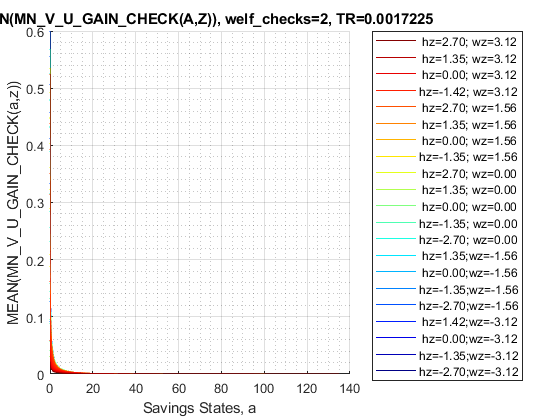

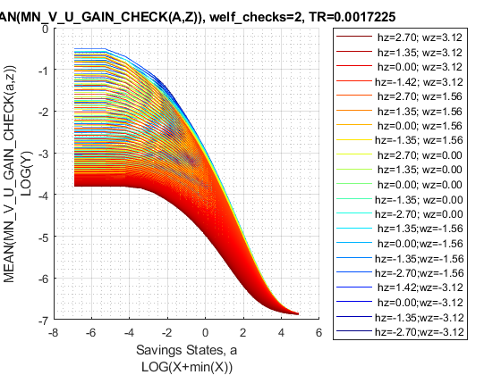

Graph Mean Consumption (*MPC: Share of Check Consumed*):

```
st_title = ['MEAN(MN\_MPC\_U\_GAIN\_CHECK(A,Z)), welf\_checks=' num2str(welf_checks) ', TR=' num2str(mp_params('TR')) ''];
mp_support_graph('cl_st_graph_title') = {st_title};
mp_support_graph('cl_st_ytitle') = {'MEAN(MN\_MPC\_U\_GAIN\_CHECK(a,z))'};
ff_graph_grid((tb_az_c{1:end, 3:end})', ar_st_eta_HS_grid, agrid, mp_support_graph);
```

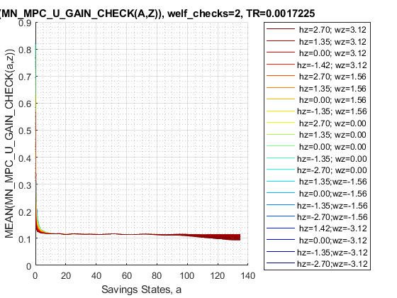

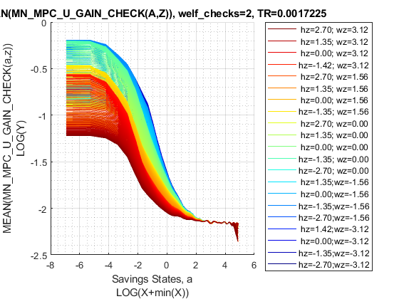

## 1.5 Analyze Marginal Value and MPC over Y(a,eta), Conditional On Kids, Marry, Age, Education

Income is generated by savings and shocks, what are the income levels generated by all the shock and savings points conditional on kids, marital status, age and educational levels. Plot on the Y axis MPC, and plot on the X axis income levels, use colors to first distinguish between different a levels, then use colors to distinguish between different eta levles.

```
% NaN(n_jgrid,n_agrid,n_etagrid,n_educgrid,n_marriedgrid,n_kidsgrid);
% 38 year old, unmarried, no kids, lower educated
% Only Household Head Shock Matters so select up to 'n_eta_H_grid'
mn_total_inc_jemk = total_inc_VFI(19,:,1:mp_params('n_eta_H_grid'),1,1,1);
mn_V_W_gain_check_use = ev19_jaeemk_check2 - ev19_jaeemk_check0;
mn_C_W_gain_check_use = ec19_jaeemk_check2 - ec19_jaeemk_check0;
```

Select Age, Education, Marital, Kids Count:s

```
% Selections
it_age = 21; % +18
it_marital = 1; % 1 = unmarried
it_kids = 1; % 1 = kids is zero
it_educ = 1; % 1 = lower education
% Select: NaN(n_jgrid,n_agrid,n_etagrid,n_educgrid,n_marriedgrid,n_kidsgrid);
mn_C_W_gain_check_jemk = mn_C_W_gain_check_use(it_age, :, 1:mp_params('n_eta_H_grid'), it_educ, it_marital, it_kids);
mn_V_W_gain_check_jemk = mn_V_W_gain_check_use(it_age, :, 1:mp_params('n_eta_H_grid'), it_educ, it_marital, it_kids);
% Reshape, so shock is the first dim, a is the second
mt_total_inc_jemk = permute(mn_total_inc_jemk,[3,2,1]);
mt_C_W_gain_check_jemk = permute(mn_C_W_gain_check_jemk,[3,2,1]);
mt_C_W_gain_check_jemk(mt_C_W_gain_check_jemk<=1e-10) = 1e-10;
mt_V_W_gain_check_jemk = permute(mn_V_W_gain_check_jemk,[3,2,1]);
mt_V_W_gain_check_jemk(mt_V_W_gain_check_jemk<=1e-10) = 1e-10;
% Generate meshed a and shock grid
[mt_eta_H, mt_a] = ndgrid(eta_H_grid(1:mp_params('n_eta_H_grid')), agrid);
```

How do shocks and a impact marginal value. First plot one asset level, variation comes only from increasingly higher shocks:

```
figure();
it_a = 1;
scatter((mt_total_inc_jemk(:,it_a)), (mt_V_W_gain_check_jemk(:,it_a)), 100);
title({'MN\_V\_W\_GAIN\_CHECK(Y(A, eta)), Lowest A, J38M0E0K0', ...
    'Each Circle is A Different Shock Level'});
xlabel('Y(a,eta) = Spouse + Household head Income Joint');
ylabel('MN\_V\_W\_GAIN\_CHECK(A, eta)');
grid on;
grid minor;
```

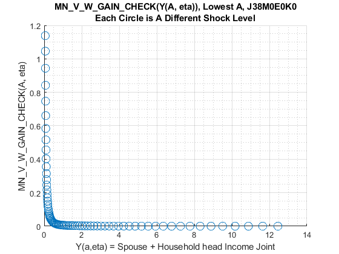

```
figure();
it_shock = 1;
scatter(log(mt_total_inc_jemk(:,it_a)), log(mt_V_W_gain_check_jemk(:,it_a)), 100);
title({'MN\_V\_W\_GAIN\_CHECK(Y(A, eta)), Lowest A, J38M0E0K0', ...
    'Each Circle is A Different Shock Level'});
xlabel(' of Y(a,eta) = Spouse + Household head Income Joint');
ylabel(' of MN\_V\_W\_GAIN\_CHECK(A, eta)');
grid on;
grid minor;
```

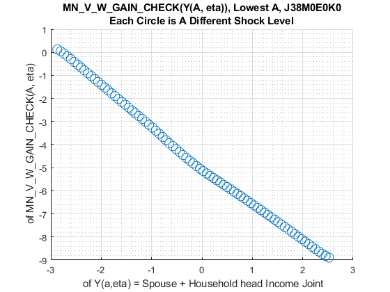

Plot all asset levels:

```
figure();
scatter((mt_total_inc_jemk(:)), (mt_V_W_gain_check_jemk(:)), 100, mt_a(:));
title({'(MN\_V\_W\_GAIN\_CHECK(Y,eta)), All A (Savings) Levels, J38M0E0K0', ...
    'Color Represent different A Savings State, Circle-Group=Shock'});
xlabel('income(a,eps)');
ylabel('MN\_V\_W\_GAIN\_CHECK(EM,J)');
grid on;
grid minor;
```

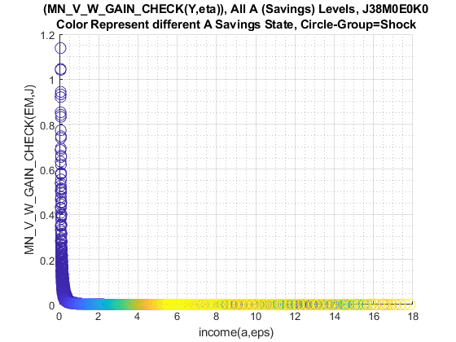

```
figure();
scatter((mt_total_inc_jemk(:)), log(mt_V_W_gain_check_jemk(:)), 100, mt_a(:));
title({'(MN\_V\_W\_GAIN\_CHECK(Y,eta)), All A (Savings) Levels, J38M0E0K0', ...
    'Color Represent different A Savings State, Circle-Group=Shock'});
xlabel('income(a,eps)');
ylabel('log of (MN\_V\_W\_GAIN\_CHECK(EM,J))');
xlim([0,7]);
grid on;
grid minor;
```

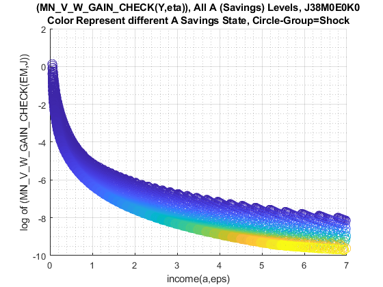

How do shocks and a impact marginal value. First plot one asset level, variation comes only from increasingly higher shocks:

```
figure();
it_a = 50;
scatter(log(mt_total_inc_jemk(:,it_a)), mt_C_W_gain_check_jemk(:,it_a), 100);
title({'MN\_C\_W\_GAIN\_CHECK(Y(A, eta)), Given A Savings Level, J38M0E0K0', ...
    'Each Circle is A Different shock Level'});
xlabel('Y(a,eta) = Spouse + Household head Income Joint');
ylabel('MN\_C\_W\_GAIN\_CHECK(A, eta)');
grid on;
grid minor;
```

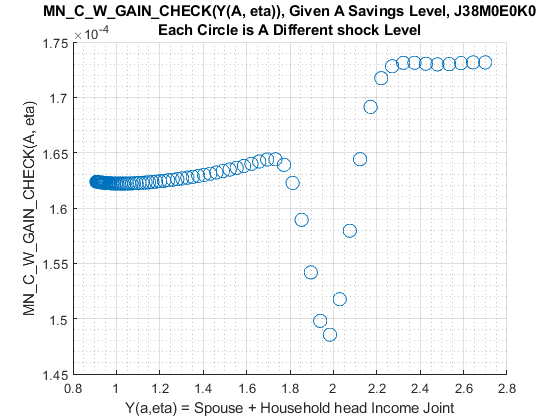

Plot all asset levels:

```
figure();
scatter((mt_total_inc_jemk(:)), (mt_C_W_gain_check_jemk(:)), 100, mt_a(:));
title({'(MN\_C\_W\_GAIN\_CHECK(Y,eta)), All A (Savings) Levels, J38M0E0K0', ...
    'Color Represent different A Savings State, Circle-Group=Shock'});
xlabel('income(a,eps)');
ylabel('MN\_C\_W\_GAIN\_CHECK(EM,J)');
grid on;
grid minor;
```

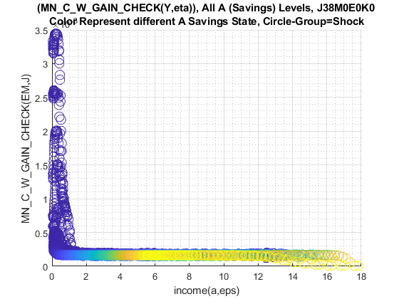

```
figure();
scatter(log(mt_total_inc_jemk(:)), log(mt_C_W_gain_check_jemk(:)), 100, mt_a(:));
title({'(MN\_C\_W\_GAIN\_CHECK(Y,eta)), All A (Savings) Levels, J38M0E0K0', ...
    'Color Represent different A Savings State, Circle-Group=Shock'});
xlabel('log of income(a,eps)');
ylabel('log of (MN\_V\_W\_GAIN\_CHECK(EM,J))');
grid on;
grid minor;
```

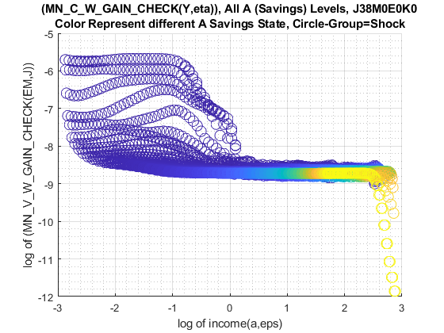

## 1.8 Analyze Kids and Marriage and Age

Aggregating over education, savings, and shocks, what are the differential effects of Marriage and Age.

```
% Generate some Data
mp_support_graph = containers.Map('KeyType', 'char', 'ValueType', 'any');
ar_row_grid = [...
    "k0M0", "K1M0", "K2M0", "K3M0", "K4M0", ...
    "k0M1", "K1M1", "K2M1", "K3M1", "K4M1"];
mp_support_graph('cl_st_xtitle') = {'Age'};
mp_support_graph('st_legend_loc') = 'best';
mp_support_graph('bl_graph_logy') = true; % do not log
mp_support_graph('st_rounding') = '6.2f'; % format shock legend
mp_support_graph('cl_scatter_shapes') = {...
    'o', 'd' ,'s', 'x', '*', ...
    'o', 'd', 's', 'x', '*'};
mp_support_graph('cl_colors') = {...
    'red', 'red', 'red', 'red', 'red'...
    'blue', 'blue', 'blue', 'blue', 'blue'};
```

MEAN(VAL(KM,J)), MEAN(AP(KM,J)), MEAN(C(KM,J))

Tabulate value and policies:

```
% Set
% NaN(n_jgrid,n_agrid,n_etagrid,n_educgrid,n_marriedgrid,n_kidsgrid);
ar_permute = [2,3,4,1,6,5];
% Value Function
st_title = ['MEAN(MN_V_U_GAIN_CHECK(KM,J)), welf_checks=' num2str(welf_checks) ', TR=' num2str(mp_params('TR'))];
tb_az_v = ff_summ_nd_array(st_title, mn_V_U_gain_check, true, ["mean"], 3, 1, cl_mp_datasetdesc, ar_permute);

xxx  MEAN(MN_V_U_GAIN_CHECK(KM,J)), welf_checks=2, TR=0.0017225  xxxxxxxxxxxxxxxxxxxxxxxxxxx
    group    kids    marry    mean_age_18    mean_age_19    mean_age_20    mean_age_21    mean_age_22    mean_age_23    mean_age_24    mean_age_25    mean_age_26    mean_age_27    mean_age_28    mean_age_29    mean_age_30    mean_age_31    mean_age_32    mean_age_33    mean_age_34    mean_age_35    …
    _____    ____    _____    ___________    ___________    ___________    ___________    ___________    ___________    ___________    ___________    ___________    ___________    ___________    ___________    ___________    ___________    ___________    ___________    ___________    ___________    …

      1       1        0        0.032313       0.031538       0.029203       0.026718       0.024639       0.022886       0.021399       0.020131       0.019042       0.018107       0.017297       0.016595       0.015946       0.015418       0.014957       0.014557        0.01421       0.013907     …
      2       2        0        0.044673       0.043637        0.04037       0.036851       0.033899         0.0314       0.029272       0.027449       0.025875       0.024514       0.023328       0.022293       0.021329       0.020537       0.019836       0.019222        0.01868       0.018201     …
      3       3        0        0.052552       0.051453       0.047283       0.043234        0.03984       0.036967       0.034521       0.032424       0.030614       0.029049       0.027686       0.026496       0.025383       0.024471       0.023664       0.022956       0.022332       0.021779     …
      4       4        0        0.059787       0.058589       0.053843       0.049266       0.045426       0.042177       0.039411        0.03704       0.034993       0.033223       0.031681       0.030333       0.029073        0.02804       0.027126       0.026325       0.025618       0.024992     …
      5       5        0         0.06554       0.064322       0.059162       0.054211        0.05006       0.046547       0.043558       0.040997       0.038787       0.036878       0.035214       0.033763       0.032402       0.031292        0.03031        0.02945       0.028693       0.028022     …
      6       1        1       0.0059295      0.0054975      0.0049865      0.0045164      0.0041185      0.0037811      0.0034951      0.0032509      0.0030403      0.0028619      0.0027092      0.0025777      0.0024592      0.0023631      0.0022806      0.0022118      0.0021541      0.0021056     …
      7       2        1       0.0083787      0.0077803      0.0070563      0.0063837      0.0058177      0.0053346      0.0049215      0.0045653      0.0042594      0.0039969      0.0037701      0.0035738      0.0033959      0.0032499       0.003123       0.003015      0.0029223      0.0028429     …
      8       3        1        0.010146      0.0094404      0.0085806      0.0077709      0.0070881      0.0065113      0.0060182      0.0055932      0.0052255      0.0049112      0.0046384      0.0044005       0.004185      0.0040086      0.0038553      0.0037249      0.0036126      0.0035162     …
      9       4        1        0.012661       0.011814        0.01075      0.0097404      0.0088898      0.0081607      0.0075394      0.0070115      0.0065566      0.0061646      0.0058234      0.0055265      0.0052562      0.0050339      0.0048395      0.0046719      0.0045273      0.0044028     …
     10       5        1        0.015891       0.014939       0.013651       0.012419       0.011375       0.010485       0.009725       0.009076      0.0085106      0.0080209      0.0075976      0.0072315      0.0068971      0.0066208      0.0063796      0.0061735      0.0059959      0.0058421     …

% Consumption Function
st_title = ['MEAN(MN_MPC_U_GAIN_CHECK(KM,J)), welf_checks=' num2str(welf_checks) ', TR=' num2str(mp_params('TR'))];
tb_az_c = ff_summ_nd_array(st_title, mn_MPC_U_gain_share_check, true, ["mean"], 3, 1, cl_mp_datasetdesc, ar_permute);

```

[output cut: 14 more lines]

Graph Mean Values:

```
st_title = ['MEAN(MN\_V\_U\_GAIN\_CHECK(KM,J)), welf\_checks=' num2str(welf_checks) ', TR=' num2str(mp_params('TR')) ''];
mp_support_graph('cl_st_graph_title') = {st_title};
mp_support_graph('cl_st_ytitle') = {'MEAN(MN\_V\_U\_GAIN\_CHECK(KM,J))'};
ff_graph_grid((tb_az_v{1:end, 4:end}), ar_row_grid, age_grid, mp_support_graph);
```

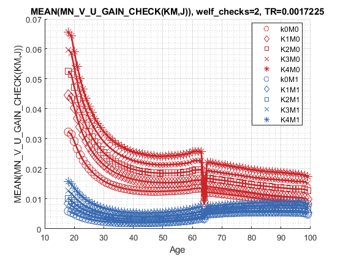

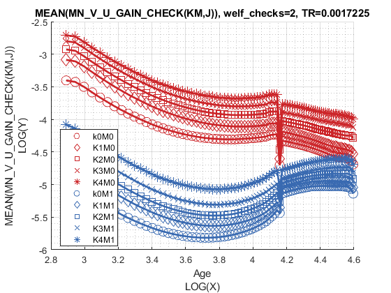

Graph Mean Consumption (*MPC: Share of Check Consumed*):

```
st_title = ['MEAN(MN\_MPC\_U\_GAIN\_CHECK(KM,J)), welf\_checks=' num2str(welf_checks) ', TR=' num2str(mp_params('TR')) ''];
mp_support_graph('cl_st_graph_title') = {st_title};
mp_support_graph('cl_st_ytitle') = {'MEAN(MN\_MPC\_U\_GAIN\_CHECK(KM,J))'};
ff_graph_grid((tb_az_c{1:end, 4:end}), ar_row_grid, age_grid, mp_support_graph);
```

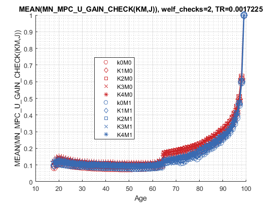

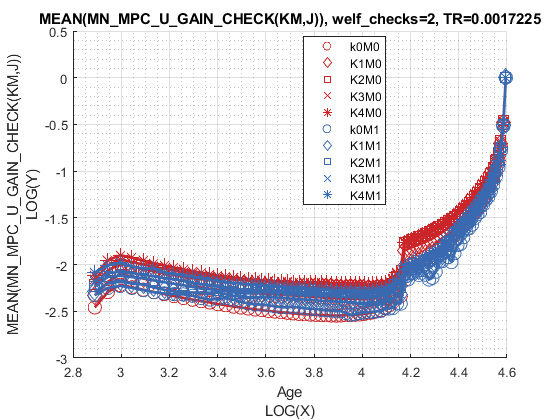

## 1.9 Analyze Education and Marriage

```
% Generate some Data
mp_support_graph = containers.Map('KeyType', 'char', 'ValueType', 'any');
ar_row_grid = ["E0M0", "E1M0", "E0M1", "E1M1"];
mp_support_graph('cl_st_xtitle') = {'Age'};
mp_support_graph('st_legend_loc') = 'best';
mp_support_graph('bl_graph_logy') = true; % do not log
mp_support_graph('st_rounding') = '6.2f'; % format shock legend
mp_support_graph('cl_scatter_shapes') = {'*', 'p', '*','p' };
mp_support_graph('cl_colors') = {'red', 'red', 'blue', 'blue'};
```

MEAN(VAL(EM,J)), MEAN(AP(EM,J)), MEAN(C(EM,J))

Tabulate value and policies:

```
% Set
% NaN(n_jgrid,n_agrid,n_etagrid,n_educgrid,n_marriedgrid,n_kidsgrid);
ar_permute = [2,3,6,1,4,5];
% Value Function
st_title = ['MEAN(MN_V_U_GAIN_CHECK(EM,J)), welf_checks=' num2str(welf_checks) ', TR=' num2str(mp_params('TR'))];
tb_az_v = ff_summ_nd_array(st_title, mn_V_U_gain_check, true, ["mean"], 3, 1, cl_mp_datasetdesc, ar_permute);

xxx  MEAN(MN_V_U_GAIN_CHECK(EM,J)), welf_checks=2, TR=0.0017225  xxxxxxxxxxxxxxxxxxxxxxxxxxx
    group    edu    marry    mean_age_18    mean_age_19    mean_age_20    mean_age_21    mean_age_22    mean_age_23    mean_age_24    mean_age_25    mean_age_26    mean_age_27    mean_age_28    mean_age_29    mean_age_30    mean_age_31    mean_age_32    mean_age_33    mean_age_34    mean_age_35    m…
    _____    ___    _____    ___________    ___________    ___________    ___________    ___________    ___________    ___________    ___________    ___________    ___________    ___________    ___________    ___________    ___________    ___________    ___________    ___________    ___________    _…

      1       0       0        0.052161       0.051299       0.048759       0.045984       0.043519       0.041317       0.039352       0.037593        0.03601       0.034589       0.033309       0.032152       0.031027       0.030089       0.029237        0.02847       0.027777        0.02715      …
      2       1       0        0.049785       0.048517       0.043186       0.038128       0.034027       0.030674       0.027912       0.025624       0.023714       0.022119       0.020773        0.01964       0.018626       0.017814        0.01712       0.016534       0.016036        0.01561      …
      3       0       1        0.011544       0.010825       0.010006      0.0092235      0.0085439      0.0079503       0.007433      0.0069803      0.0065805      0.0062306      0.0059235      0.0056516      0.0054012      0.0051932      0.0050103      0.0048522      0.0047144      0.0045957      …
      4       1       1       0.0096585      0.0089631      0.0080043      0.0071088       0.006372      0.0057587      0.0052467      0.0048184      0.0044564      0.0041517      0.0038919      0.0036724      0.0034762      0.0033173      0.0031809      0.0030667      0.0029705      0.0028881      …

% Consumption
st_title = ['MEAN(MN_MPC_U_GAIN_CHECK(EM,J)), welf_checks=' num2str(welf_checks) ', TR=' num2str(mp_params('TR'))];
tb_az_c = ff_summ_nd_array(st_title, mn_MPC_U_gain_share_check, true, ["mean"], 3, 1, cl_mp_datasetdesc, ar_permute);

xxx  MEAN(MN_MPC_U_GAIN_CHECK(EM,J)), welf_checks=2, TR=0.0017225  xxxxxxxxxxxxxxxxxxxxxxxxxxx
    group    edu    marry    mean_age_18    mean_age_19    mean_age_20    mean_age_21    mean_age_22    mean_age_23    mean_age_24    mean_age_25    mean_age_26    mean_age_27    mean_age_28    mean_age_29    mean_age_30    mean_age_31    mean_age_32    mean_age_33    mean_age_34    mean_age_35    m…
    _____    ___    _____    ___________    ___________    ___________    ___________    ___________    ___________    ___________    ___________    ___________    ___________    ___________    ___________    ___________    ___________    ___________    ___________    ___________    ___________    _…

      1       0       0        0.09247        0.10277        0.10886        0.10804        0.10737        0.10669         0.1062        0.10569        0.10512        0.10482        0.10443        0.10407        0.10357        0.10334        0.10301        0.10288        0.10263        0.10245       …
      2       1       0        0.11649        0.14189        0.15288        0.14697         0.1408        0.13569         0.1308        0.12668        0.12297        0.11977        0.11682        0.11437        0.11174        0.10981        0.10804        0.10646        0.10519        0.10401       …
      3       0       1        0.09821        0.10337        0.10589        0.10515        0.10424         0.1031        0.10254         0.1028        0.10227        0.10103         0.1005        0.10063        0.10055        0.10011       0.099251       0.098615       0.097864       0.097329       …
      4       1       1        0.11712        0.13122        0.13364        0.12898        0.12579        0.12299          0.118        0.11464        0.11249        0.11052        0.10776        0.10563        0.10422        0.10294        0.10087       0.099205       0.098375       0.098817       …
```

Graph Mean Values:

```
st_title = ['MEAN(MN\_V\_U\_GAIN\_CHECK(EM,J)), welf\_checks=' num2str(welf_checks) ', TR=' num2str(mp_params('TR')) ''];
mp_support_graph('cl_st_graph_title') = {st_title};
mp_support_graph('cl_st_ytitle') = {'MEAN(MN\_V\_U\_GAIN\_CHECK(EM,J))'};
ff_graph_grid((tb_az_v{1:end, 4:end}), ar_row_grid, age_grid, mp_support_graph);
```

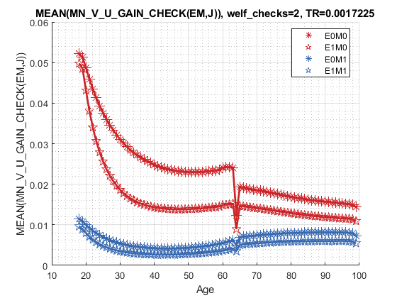

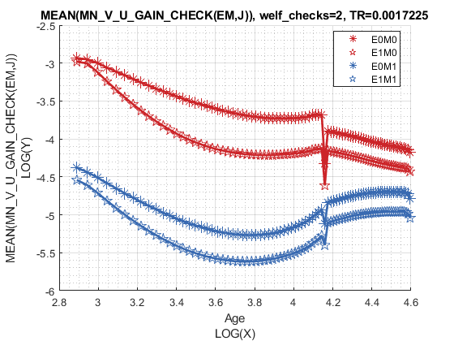

Graph Mean Consumption (*MPC: Share of Check Consumed*):

```
st_title = ['MEAN(MN\_MPC\_U\_GAIN\_CHECK(EM,J)), welf\_checks=' num2str(welf_checks) ', TR=' num2str(mp_params('TR')) ''];
mp_support_graph('cl_st_graph_title') = {st_title};
mp_support_graph('cl_st_ytitle') = {'MEAN(MN\_MPC\_U\_GAIN\_CHECK(EM,J))'};
ff_graph_grid((tb_az_c{1:end, 4:end}), ar_row_grid, age_grid, mp_support_graph);
```

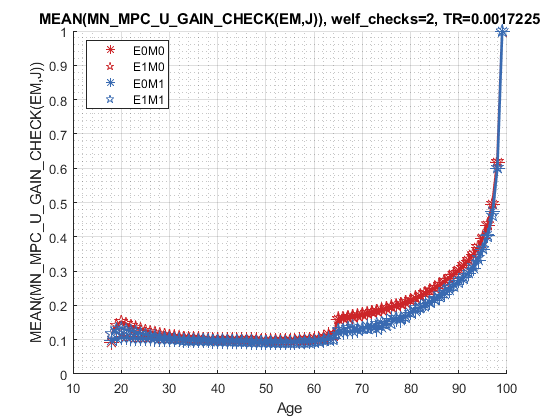

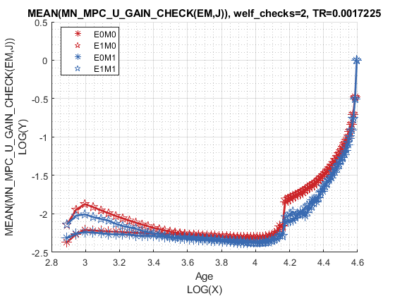